# Primer Trabajo Practico - Análisis Exploratorio y Limpieza de Datos

Alex Gabriel Cerutti

23 de septiembre de 2022

## DataSet

Game of Thrones (Juego de Tronos) es un exitoso programa de television de fantasia basado en la igualmente famosa serie de libros “A Song of Fire and Ice (Cancion de Hielo y Fuego)” de George RR Martin. El programa es conocido por su trama politica enormemente complicada, gran cantidad de personajes y sus frecuentes muertes de personajes. En este trabajo Practico se analizará archivo characterDeaths.csv que contiene los datos respecto a las muertes de los personajes de los diferentes libros, cabe aclarar que incluye aquellos personajes que aun se encuentran vivos.

### **Variables**

- **Name** : Nombre del personaje
- **Allegiances** : Casa a la que se encuentra aliado el personaje
- **Death.Year** : Anio de fallecimmiento (en caso que no contenga datos, indica que el personaje está vivo)
- **Book.of.Death** : Libro en el que fallecio
- **Death.Chapter** : Capitulo del libro en el que fallecio
- **Book.Intro.Chapter**: Capitulo del libro en el que aparece por primera vez
- **Gender** : Genero del personaje (0-Femenino ; 1-Masculino)
- **Nobility** : Indica si pertenece a familia noble (1) o no(0)
- **GoT** : Indica si el personaje aparece o no en el libro 1 (*Game of Thrones*)
- **CoK** : Indica si el personaje aparece o no en el libro 2 (*Clash of Kings*)
- **SoS** : Indica si el personaje aparece o no en el libro 3 (*Storm of Swords*)
- **FfC** : Indica si el personaje aparece o no en el libro 4 (*Feast of Crows*)
- **DwD** : Indica si el personaje aparece o no en el libro 5 (*Dance with Dragons*)

## Ejercicio 1

Identifique el directorio de trabajo

```r
getwd()
```

```
## [1] "C:/Users/Alex/Desktop"
```

## Ejercicio 2

Cargue el archivo characterDeaths.csv (el mismo se encuentra separado por , ) dentro de una variable llamda GOT

```r
GOT = read.csv('C:/characterDeaths.csv', header = TRUE, sep=",", na.strings = c(''))
```

## Ejercicio 3

De que clase es el objeto GOT?

```r
class(GOT)
```

```
## [1] "data.frame"
```

Es de clase “data.frame”

## Ejercicio 4

Obtenga la estructura global del objeto con un solo comando e indique

1. Cantidad de observaciones
2. Cantidad de columnas (o variables)
3. Nombre de cada variable del dataframe
4. Tipo de dato de cada variable del dataframe

```r
str(GOT)
```

```
## 'data.frame':    917 obs. of  13 variables:
##  $ Name              : chr  "Addam Marbrand" "Aegon Frey (Jinglebell)" "Aegon Targaryen" "Adrack Humble" ...
##  $ Allegiances       : chr  "Lannister" "None" "House Targaryen" "House Greyjoy" ...
##  $ Death.Year        : int  NA 299 NA 300 NA NA 300 300 NA NA ...
##  $ Book.of.Death     : int  NA 3 NA 5 NA NA 4 5 NA NA ...
##  $ Death.Chapter     : int  NA 51 NA 20 NA NA 35 NA NA NA ...
##  $ Book.Intro.Chapter: int  56 49 5 20 NA NA 21 59 11 0 ...
##  $ Gender            : int  1 1 1 1 1 1 1 0 1 1 ...
##  $ Nobility          : int  1 1 1 1 1 1 1 1 1 0 ...
##  $ GoT               : int  1 0 0 0 0 0 1 1 0 0 ...
##  $ CoK               : int  1 0 0 0 0 1 0 1 1 0 ...
##  $ SoS               : int  1 1 0 0 1 1 1 1 0 1 ...
##  $ FfC               : int  1 0 0 0 0 0 1 0 1 0 ...
##  $ DwD               : int  0 0 1 1 0 0 0 1 0 0 ...
```

Contiene 917 observaciones, y las siguientes 13 columnas con su tipo: (Nombre, tipo) Name, caracter Allegiances, caracter Death.Year, entero Book.of.Death, entero Death.Chapter, entero Book.Intro.Chapter, entero Gender, entero Nobility, entero GoT, entero CoK, entero SoS, entero FfC, entero DwD, entero

## Ejercicio 5

En caso que las siguientes columnas no sean del tipo factor, conviertalas

- Gender
- Nobility
- GoT
- CoK
- SoS
- FfC
- DwD

Porque es recomendable que dichas variables sean factor?

```r
GOT$Gender <- as.factor(GOT$Gender)
GOT$Nobility <- as.factor(GOT$Nobility)
GOT$GoT <- as.factor(GOT$GoT)
GOT$CoK <- as.factor(GOT$CoK)
GOT$SoS <- as.factor(GOT$SoS)
GOT$FfC <- as.factor(GOT$FfC)
GOT$DwD <- as.factor(GOT$DwD)
```

Como todos eran enteros, se los convirtio a factor. Es recomendable utilizar factor ya que permite trabajar las variables como categoricas, pudiendo realizar por ejemplo una tabla de frecuencias para cada categoria

## Ejercicio 6

Genere una nueva columna que indique si el personaje esta vivo o no.

```r
GOT$Is.Alive[!is.na(GOT$Death.Year) | !is.na(GOT$Book.of.Death) | !is.na(GOT$Death.Chapter)] <- "No"
GOT$Is.Alive[is.na(GOT$Death.Year) & is.na(GOT$Book.of.Death) & is.na(GOT$Death.Chapter)] <- "Yes"
```

Se considera que un personaje esta vivo solo si en las 3 variables correspondientes a su muerte existen valores NA

## Ejercicio 7

Genere dos nuevos data frame, uno con aquellos personajes vivos y otro con los personajes ya fallecidos.

```r
Alive <- GOT[GOT$Is.Alive == "Yes",]
Dead <- GOT[GOT$Is.Alive == "No",]
```

## Ejercicio 8

Genere una tabla de frecuencias identificando la cantidad de muertes por anio (no incluir personajes vivos)

```r
table(as.factor(Dead$Death.Year))
```

```
##
## 297 298 299 300
##   3  46 156 100
```

## Ejercicio 9

Genere un grafico de torta en el que se muestren la cantidad de personajes muertos por genero. Que observa?

*Nota*: Agregue al grafico un titulo apropiado

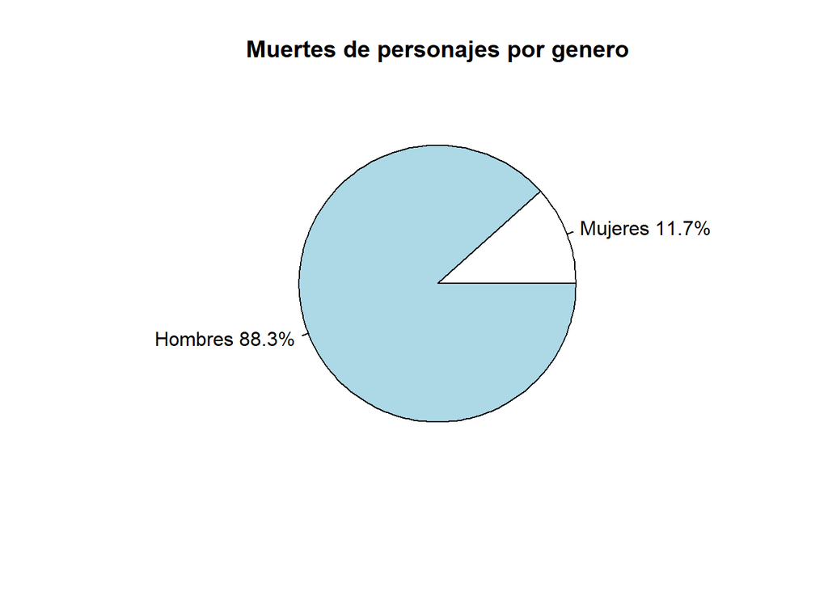

```r
x <- table(as.factor(Dead$Gender))
piepercent<- round(100*x/sum(x), 1)
lbls <- c("Mujeres", "Hombres")
lbls <- paste(lbls, piepercent)
lbls <- paste(lbls,"%",sep="")
pie(x, labels = lbls, main = "Muertes de personajes por genero")
```

## Ejercicio 10

Genere una tabla de contingencias en la que se muestren la cantidad de muertes por anio y genero.

```r
tabla <- table(Dead$Death.Year, Dead$Gender)
colnames(tabla) <- c("Mujer","Hombre")
tabla
```

```
##
##       Mujer Hombre
##   297     0      3
##   298     3     43
##   299    15    141
##   300    18     82
```

## Ejercicio 11

Realice un histograma de la variable Book.Intro.Chapter.

- Trabaje con frecuencias relativas y clases.
- Agregue nombres a los ejes y al diagrama en general

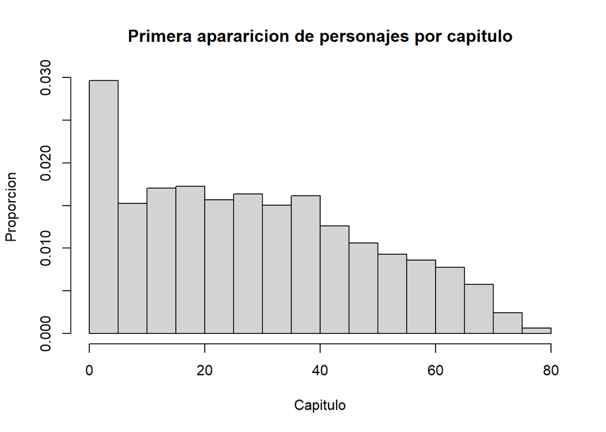

```r
hist(GOT$Book.Intro.Chapter, freq = F, main = "Primera apararicion de personajes por capitulo",
     xlab = "Capitulo", ylab = "Proporcion", nclass = 20)
```

## Ejercicio 12

Indique si la variable Book.Intro.Chapter responde a distribucion normal. Realice un grafico cuantil cuantil

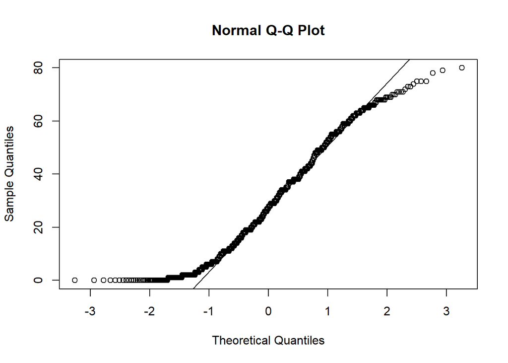

```r
qqnorm(GOT$Book.Intro.Chapter)
qqline(GOT$Book.Intro.Chapter)
```

```r
length(GOT$Book.Intro.Chapter)
```

```
## [1] 917
```

```r
shapiro.test(GOT$Book.Intro.Chapter)
```

```
##
##  Shapiro-Wilk normality test
##
## data:  GOT$Book.Intro.Chapter
## W = 0.95617, p-value = 8.44e-16
```

En el grafico se puede observar que a pesar de que los valores centrales si parecen corresponder a una distribucion normal, al tener en cuenta al resto no. Luego de verificar que la cantidad de observaciones sea menor a 5000, se opto por realizar la prueba de Shapiro Wilk, la cual arrojo un resultado mucho menor a 0.05, por lo que se puede rechazar la hipotesis nula y afirmar que la distribucion no corresponda a una normal

## Ejercicio 13

Utilizando el data frame GOT identifique si hay valores NA y trabajelos de la manera mas conveniente en caso que corresponda. Justifique cada criterio

```r
na_count <- sapply(GOT, function(y) sum(length(which(is.na(y)))))
na_count <- data.frame(na_count)
na_count
```

```
##                    na_count
## Name                      0
## Allegiances               0
## Death.Year              612
## Book.of.Death           610
## Death.Chapter           618
## Book.Intro.Chapter       12
## Gender                    0
## Nobility                  0
## GoT                       0
## CoK                       0
## SoS                       0
## FfC                       0
## DwD                       0
## Is.Alive                  0
```

Se puede observar que hay 4 columnas que poseen valores NA, 3 de las cuales corresponden a la muerte de personajes. En un principio se afirmo de que si existen valores NA en la columna de Death.Year significa de que el personaje sigue vivo, por lo que se cambiaran estos valores NA por “Alive” en los casos donde estas 3 columnas sean NA simultaneamente.

```r
GOT$Death.Year[is.na(GOT$Death.Year) & is.na(GOT$Book.of.Death) & is.na(GOT$Death.Chapter)] <- "Alive"
GOT$Book.of.Death[GOT$Death.Year == "Alive" & is.na(GOT$Book.of.Death) & is.na(GOT$Death.Chapter)] <- "Alive"
GOT$Death.Chapter[GOT$Death.Year == "Alive" & GOT$Book.of.Death == "Alive" & is.na(GOT$Death.Chapter)] <- "Alive"

na_count <- sapply(GOT, function(y) sum(length(which(is.na(y)))))
na_count <- data.frame(na_count)
na_count
```

```
##                    na_count
## Name                      0
## Allegiances               0
## Death.Year                4
## Book.of.Death             2
## Death.Chapter            10
## Book.Intro.Chapter       12
## Gender                    0
## Nobility                  0
## GoT                       0
## CoK                       0
## SoS                       0
## FfC                       0
## DwD                       0
## Is.Alive                  0
```

En el caso de que solo una o 2 columnas sean NA, se interpreta que el personaje probablemente este muerto, por lo que se reemplazaran los NA por las modas correspondientes

```r
sort(table(as.factor(GOT$Death.Year)))
```

```
##
##   297   298   300   299 Alive
##     3    46   100   156   608
```

```r
sort(table(as.factor(GOT$Book.of.Death)))
```

```
##
##     4     1     5     2     3 Alive
##    27    49    61    73    97   608
```

```r
sort(table(as.factor(GOT$Death.Chapter)))
```

```
##
##     1    16    17    23    25     3    36    38    40    43    45    48    52
##     1     1     1     1     1     1     1     1     1     1     1     1     1
##    53    73    74    76    80     9    11    12     2    24    30    47    49
##     1     1     1     1     1     1     2     2     2     2     2     2     2
##    59     6    60    65    67    72    75    77    14    32    44    58    63
##     2     2     2     2     2     2     2     2     3     3     3     3     3
##    68     7    70    26    41    57    10    21    27    61     0    18    29
##     3     3     3     4     4     4     5     5     5     5     6     6     6
##    50    56    62    19    39    42    46    33    35    31    37    64     4
##     6     6     6     7     7     7     7     8     8     9     9     9    10
##    55    69    66    20    51    34 Alive
##    11    11    12    13    14    16   608
```

Siendo las modas para Death.Year, Book.of.Death, Death.Chapter, 299, 3 y 34 respectivamente (no se tienen en cuenta las modas correspondientes a cantidad de personajes vivos)

```r
GOT$Death.Year[is.na(GOT$Death.Year)] <- 299
GOT$Book.of.Death[is.na(GOT$Book.of.Death)] <- 3
GOT$Death.Chapter[is.na(GOT$Death.Chapter)] <- 34
na_count <- sapply(GOT, function(y) sum(length(which(is.na(y)))))
na_count <- data.frame(na_count)
na_count
```

```
##                    na_count
## Name                      0
## Allegiances               0
## Death.Year                0
## Book.of.Death             0
## Death.Chapter             0
## Book.Intro.Chapter       12
## Gender                    0
## Nobility                  0
## GoT                       0
## CoK                       0
## SoS                       0
## FfC                       0
## DwD                       0
## Is.Alive                  0
```

Ahora para los valores de Book.Intro.Chapter, se puede observar en el grafico del punto 11 que hay una moda en valores cercanos al 0, como se puede verificar en la siguiente tabla de frecuencias

```r
sort(table(as.factor(GOT$Book.Intro.Chapter)))
```

```
##
## 72 74 78 79 80 36 67 73 58 70 75 45 47 54 71 46 60 61 69  9 51 57 64 17 39 40
##  1  1  1  1  1  2  2  2  3  3  3  4  4  4  4  5  5  5  5  6  6  6  6  7  7  7
## 52 62 66  8 32 44 63 24 25 53 65 68  4 15 20 31 50 13 27 28 48 56  3 33 10 23
##  7  7  7  8  8  8  8  9  9  9  9  9 10 10 10 10 10 11 11 11 11 11 12 12 13 13
## 35 43  5 14 21 26 30 42 59 12 16 18 55 41 49  6  7 29  1 34 22 11 37 38 19  2
## 13 13 14 14 14 14 14 14 14 15 15 16 16 18 18 20 22 24 25 25 26 27 28 29 30 32
##  0
## 41
```

Donde el valor mas frecuente es el 0, debido a esto es que se procedera a reemplazar estos NA por el valor correspondiente a la moda que es 0

```r
GOT$Book.Intro.Chapter[is.na(GOT$Book.Intro.Chapter)] <- 0
na_count <- sapply(GOT, function(y) sum(length(which(is.na(y)))))
na_count <- data.frame(na_count)
na_count
```

```
##                    na_count
## Name                      0
## Allegiances               0
## Death.Year                0
## Book.of.Death             0
## Death.Chapter             0
## Book.Intro.Chapter        0
## Gender                    0
## Nobility                  0
## GoT                       0
## CoK                       0
## SoS                       0
## FfC                       0
## DwD                       0
## Is.Alive                  0
```

```r
GOT[1:20,]
```

```
##                                 Name     Allegiances Death.Year Book.of.Death
## 1                     Addam Marbrand       Lannister      Alive         Alive
## 2            Aegon Frey (Jinglebell)            None        299             3
## 3                    Aegon Targaryen House Targaryen      Alive         Alive
## 4                      Adrack Humble   House Greyjoy        300             5
## 5                     Aemon Costayne       Lannister      Alive         Alive
## 6                    Aemon Estermont       Baratheon      Alive         Alive
## 7  Aemon Targaryen (son of Maekar I)   Night's Watch        300             4
## 8                         Aenys Frey            None        300             5
## 9                      Aeron Greyjoy   House Greyjoy      Alive         Alive
## 10                            Aethan   Night's Watch      Alive         Alive
## 11                             Aggar   House Greyjoy        299             2
## 12                              Aggo House Targaryen      Alive         Alive
## 13                     Alan of Rosby   Night's Watch        300             5
## 14                           Alayaya            None      Alive         Alive
```

[output cut: 48 more lines]

Se puede observar que los datos se encuentran ordenados por el nombre. Sin embargo en algunos casos se nota que no se esta respetando el criterio de ordenamiento, por ejemplo en la fila 3 y 4 donde Adrack deberia estar antes que Aegon, por lo que se procedera a reordenar en base al nombre con el fin de facilitar las busquedas manuales en el dataframe

```r
library(dplyr)
GOT <- arrange(GOT,Name)
GOT[1:20,]
```

```
##                                 Name     Allegiances Death.Year Book.of.Death
## 1                     Addam Marbrand       Lannister      Alive         Alive
## 2                      Adrack Humble   House Greyjoy        300             5
## 3            Aegon Frey (Jinglebell)            None        299             3
## 4                    Aegon Targaryen House Targaryen      Alive         Alive
## 5                     Aemon Costayne       Lannister      Alive         Alive
## 6                    Aemon Estermont       Baratheon      Alive         Alive
## 7  Aemon Targaryen (son of Maekar I)   Night's Watch        300             4
## 8                         Aenys Frey            None        300             5
## 9                      Aeron Greyjoy   House Greyjoy      Alive         Alive
## 10                            Aethan   Night's Watch      Alive         Alive
## 11                             Aggar   House Greyjoy        299             2
## 12                              Aggo House Targaryen      Alive         Alive
## 13                     Alan of Rosby   Night's Watch        300             5
## 14                           Alayaya            None      Alive         Alive
```

[output cut: 48 more lines]